# tarea_regresion

Importamos los datos y los analizamos

```r
library(readxl)
library(FactoMineR)
library(stargazer)
library(ggplot2)
library(GGally)
```

```r
Datos <- read_excel('C:/Datasets/Happiness.xlsx', sheet='HapinessLAB 2016',range = cell_cols('A:J'))
```

```r
Datos <- data.frame(Datos)
Datos$country = row.names(Datos$country)
```

```r
stargazer(Datos, type = 'text')
```

```
====================================================================================
Statistic                         N   Mean  St. Dev.  Min   Pctl(25) Pctl(75)  Max
------------------------------------------------------------------------------------
log_gdp_per_capita               141 9.207   1.356   2.736   8.249    10.247  11.459
social_support                   141 0.812   0.126   0.290   0.754    0.911   0.985
healthy_life_expectancy_at_birth 141 63.010  8.158   43.377  57.229   69.067  80.700
freedom_to_make_life_choices     141 0.762   0.129   0.304   0.685    0.863   0.984
generosity                       141 -0.010  0.145   -0.274  -0.108   0.082   0.486
perceptions_of_corruption        141 0.741   0.189   0.047   0.698    0.864   0.970
positive_affect                  141 0.712   0.099   0.465   0.636    0.793   0.925
negative_affect                  141 0.285   0.091   0.108   0.220    0.339   0.570
life_ladder                      141 5.400   1.145   2.693   4.521    6.140   7.660
------------------------------------------------------------------------------------
```

Definimos la cantidad de columnas y filas

```r
N <- nrow(Datos)
P <- ncol(Datos)
```

Se hace la partición de elementos para el entrenamiento y las pruebas

```r
pPorcTraining=3/4
```

```r
set.seed(123456789)
random<-sample(1:N)
```

```r
num.Datos.training<-as.integer(pPorcTraining*N)
```

```r
set.seed(123456789)
training.indices<-random[1:num.Datos.training]
testing.indices <-random[(num.Datos.training+1):N]
```

```r
training.set <- Datos[training.indices,]
testing.set  <- Datos[testing.indices,]
```

```r
stargazer(training.set, type = 'text')
```

```
====================================================================================
Statistic                         N   Mean  St. Dev.  Min   Pctl(25) Pctl(75)  Max
------------------------------------------------------------------------------------
log_gdp_per_capita               105 9.202   1.263   5.135   8.158    10.269  11.111
social_support                   105 0.810   0.130   0.290   0.748    0.912   0.985
healthy_life_expectancy_at_birth 105 62.769  7.850   44.011  57.398   68.698  75.089
freedom_to_make_life_choices     105 0.761   0.133   0.304   0.685    0.863   0.984
generosity                       105 -0.010  0.137   -0.268  -0.108   0.082   0.402
perceptions_of_corruption        105 0.745   0.179   0.210   0.698    0.862   0.970
positive_affect                  105 0.705   0.098   0.465   0.636    0.787   0.874
negative_affect                  105 0.286   0.096   0.108   0.215    0.346   0.570
life_ladder                      105 5.393   1.188   2.693   4.514    6.170   7.660
------------------------------------------------------------------------------------
```

```r
stargazer(testing.set, type = 'text')
```

```
===================================================================================
Statistic                        N   Mean  St. Dev.  Min   Pctl(25) Pctl(75)  Max
-----------------------------------------------------------------------------------
log_gdp_per_capita               36 9.220   1.618   2.736   8.665    10.224  11.459
social_support                   36 0.819   0.113   0.524   0.784    0.902   0.945
healthy_life_expectancy_at_birth 36 63.711  9.080   43.377  55.904   70.283  80.700
freedom_to_make_life_choices     36 0.763   0.118   0.467   0.688    0.858   0.924
generosity                       36 -0.008  0.169   -0.274  -0.105   0.078   0.486
perceptions_of_corruption        36 0.730   0.218   0.047   0.707    0.876   0.949
positive_affect                  36 0.732   0.101   0.535   0.643    0.810   0.925
negative_affect                  36 0.283   0.076   0.111   0.225    0.330   0.468
life_ladder                      36 5.418   1.023   3.333   4.548    6.044   7.245
-----------------------------------------------------------------------------------
```

Existe una diferencia relativamente amplia entre el min de log_gdp_per_capit del set de entrenamiento y el de prueba, lo que podría explicar la diferencia en la desviación estándar, sin embargo la media y los demás percentiles mantienen deltas aceptables, por lo que se continúa con las semillas vistas arriba Igualmente se encuentran deltas altos con respecto a la desviacion estandar de healthy_life_expectancy_at_birth entre ambos sets, sin embargo los otros numeros se observan aceptables de momento

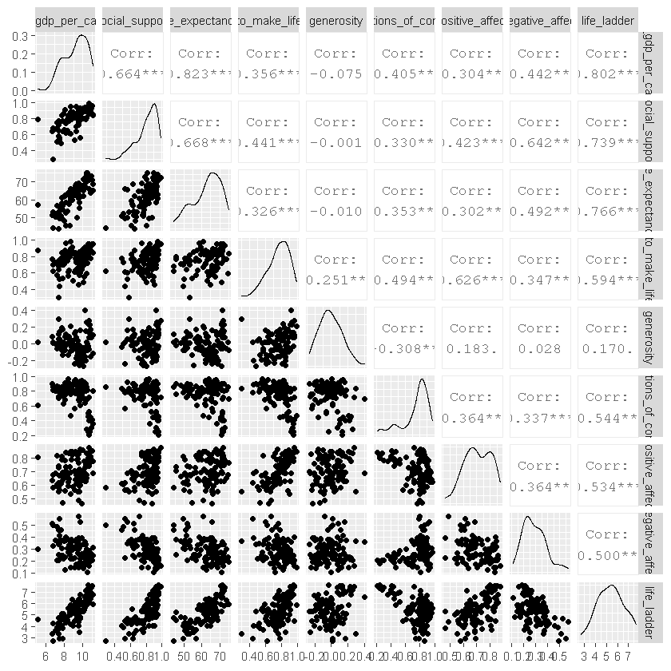

```r
GGally::ggpairs(training.set)
```

A continuación definimos la variable life_ladder en función de las otras 8:

```r
especificacion <- "life_ladder ~ log_gdp_per_capita + social_support + healthy_life_expectancy_at_birth + freedom_to_make_life_choices + generosity + perceptions_of_corruption + positive_affect + negative_affect"
```

```r
Modelo <- lm(especificacion, data = Datos)
stargazer(Modelo, type="text")
```

```
============================================================
                                     Dependent variable:
                                 ---------------------------
                                         life_ladder
------------------------------------------------------------
log_gdp_per_capita                        0.230***
                                           (0.062)

social_support                            2.553***
                                           (0.587)

healthy_life_expectancy_at_birth          0.037***
                                           (0.010)

freedom_to_make_life_choices               1.093**
                                           (0.490)

generosity                                  0.498
                                           (0.336)

perceptions_of_corruption                  -0.455
                                           (0.296)

positive_affect                           2.061***
                                           (0.607)

negative_affect                             0.577
                                           (0.653)

Constant                                  -3.272***
                                           (0.714)

------------------------------------------------------------
Observations                                 141
R2                                          0.793
Adjusted R2                                 0.780
Residual Std. Error                   0.536 (df = 132)
F Statistic                        63.208*** (df = 8; 132)
============================================================
Note:                            *p<0.1; **p<0.05; ***p<0.01
```

Con lo anterior, podemos observar poca relevancia estadística para las variables generosity, perceptions of corruption y negative affect. R2 nos indica una proyección alta de casi 80%

Procedemos a comparar resultados con los publicados:

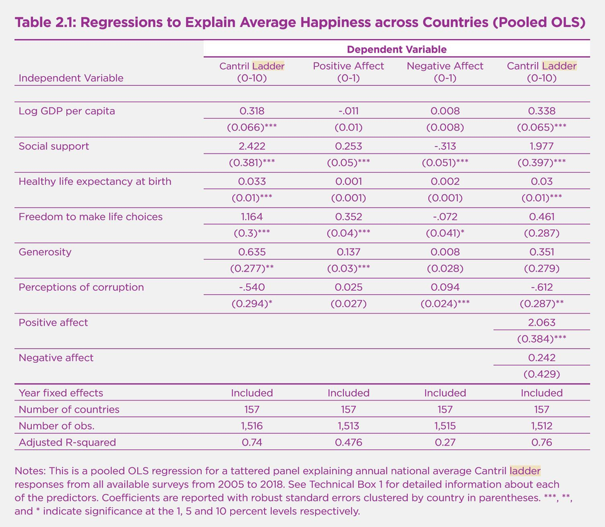

A continuación comparamos los mismos resultados para todo el universo y los dos sets de entrenamiento y prueba:

```r
ModeloTot <- lm(especificacion, data = Datos)
ModeloEnt <- lm(especificacion, data = training.set)
ModeloPru <- lm(especificacion, data = testing.set)

stargazer(ModeloTot,ModeloEnt,ModeloPru, type="text")
```

```
======================================================================================================
                                                          Dependent variable:
                                 ---------------------------------------------------------------------
                                                              life_ladder
                                           (1)                    (2)                    (3)
------------------------------------------------------------------------------------------------------
log_gdp_per_capita                      0.230***                0.354***                0.007
                                         (0.062)                (0.075)                (0.108)

social_support                          2.553***                2.074***                2.661*
                                         (0.587)                (0.625)                (1.330)

healthy_life_expectancy_at_birth        0.037***                0.031**                0.062***
                                         (0.010)                (0.012)                (0.018)

freedom_to_make_life_choices             1.093**                1.348**                 -0.361
                                         (0.490)                (0.522)                (1.093)

generosity                                0.498                 0.913**                 -0.277
                                         (0.336)                (0.399)                (0.569)

perceptions_of_corruption                -0.455                 -0.708**                0.377
                                         (0.296)                (0.349)                (0.521)

positive_affect                         2.061***                1.512**                3.677***
                                         (0.607)                (0.663)                (1.269)

negative_affect                           0.577                  0.525                  0.176
                                         (0.653)                (0.692)                (1.496)

Constant                                -3.272***              -3.169***               -3.512**
                                         (0.714)                (0.824)                (1.347)

------------------------------------------------------------------------------------------------------
Observations                               141                    105                     36
R2                                        0.793                  0.835                  0.805
Adjusted R2                               0.780                  0.822                  0.748
Residual Std. Error                 0.536 (df = 132)        0.502 (df = 96)        0.514 (df = 27)
F Statistic                      63.208*** (df = 8; 132) 60.946*** (df = 8; 96) 13.956*** (df = 8; 27)
======================================================================================================
Note:                                                                      *p<0.1; **p<0.05; ***p<0.01
```

Al comparar los diferentes sets de datos, se esperaría que tengan un error estandar similar, ya que el primer grupo contiene a los dos siguientes. Sin embargo, se pueden apreciar diferencias altas entre los grupos que suguiere que no son estadísticamente similares a pesar de que los sets 2 y 3 son subgrupos del set 1.

Con la tabla anterior, se observa que negative_affect tiene poca relevancia estadística constantemente para los 3 escenarios, por lo que procederemos a eliminirla y a comparar los resultados.

```r
especificacion <- "life_ladder ~ log_gdp_per_capita + social_support + healthy_life_expectancy_at_birth + freedom_to_make_life_choices + generosity + perceptions_of_corruption + positive_affect"
```

```r
ModeloTotOmit <- lm(especificacion, data = Datos)
stargazer(ModeloTot,ModeloTotOmit, type="text")
```

```
================================================================================
                                               Dependent variable:
                                 -----------------------------------------------
                                                   life_ladder
                                           (1)                     (2)
--------------------------------------------------------------------------------
log_gdp_per_capita                      0.230***                0.240***
                                         (0.062)                 (0.061)

social_support                          2.553***                2.332***
                                         (0.587)                 (0.530)

healthy_life_expectancy_at_birth        0.037***                0.036***
                                         (0.010)                 (0.010)

freedom_to_make_life_choices             1.093**                 1.082**
                                         (0.490)                 (0.490)

generosity                                0.498                   0.526
                                         (0.336)                 (0.334)

perceptions_of_corruption                -0.455                  -0.393
                                         (0.296)                 (0.288)

positive_affect                         2.061***                2.002***
                                         (0.607)                 (0.603)

negative_affect                           0.577
                                         (0.653)

Constant                                -3.272***               -2.944***
                                         (0.714)                 (0.609)

--------------------------------------------------------------------------------
Observations                               141                     141
R2                                        0.793                   0.792
Adjusted R2                               0.780                   0.781
Residual Std. Error                 0.536 (df = 132)        0.536 (df = 133)
F Statistic                      63.208*** (df = 8; 132) 72.245*** (df = 7; 133)
================================================================================
Note:                                                *p<0.1; **p<0.05; ***p<0.01
```

Podemos observar que la proyección, al eliminar negative_affect, se mantiene dentro del mismo margen e incluso mejora con respecto a R2 ajustado. Sin embargo, se ve un impacto en la constante. Se podría interpretar, por lo tanto, que la variable omitida no tiene relevancia. Sin embargo, se aplicará la prueba de Akaike para validar de manera objetiva la hipótesis anterior.

```r
OLS.AIC.OMI=AIC(ModeloTotOmit)
OLS.AIC.TOT=AIC(ModeloTot)
AIC=cbind(TOTAL=OLS.AIC.TOT, OMITIDO=OLS.AIC.OMI)
print(AIC)
```

```
        TOTAL  OMITIDO
[1,] 235.1615 233.9934
```

Con lo anterior, observamos que la pérdida de información para el modelo donde se omite negative_affect es menor, lo que confirma la hipótesis

### Multicolinealidad

Según el gráfico pairs anterior, se aprecian ciertos momentos de fuerte correlación entre variables, sin embargo, consideramos que es un criterio subjetivo y poco eficiente. Para demostrar la existencia de multicolinealidad, se aplicará el test VIF.

```r
A=car::vif(ModeloEnt)
B=car::vif(ModeloPru)
C=car::vif(ModeloTot)
TABLA=rbind(A,B,C)
row.names(TABLA)=c("ENTRENAMIENTO", "PRUEBA", "TOTAL")
print(TABLA)
```

```
              log_gdp_per_capita social_support
ENTRENAMIENTO           3.676944       2.723172
PRUEBA                  4.028820       3.017504
TOTAL                   3.421954       2.642344
              healthy_life_expectancy_at_birth freedom_to_make_life_choices
ENTRENAMIENTO                         3.470225                     2.006958
PRUEBA                                3.357444                     2.189476
TOTAL                                 3.282319                     1.951232
              generosity perceptions_of_corruption positive_affect
ENTRENAMIENTO   1.233426                  1.618684        1.746133
PRUEBA          1.220224                  1.715589        2.181914
TOTAL           1.154253                  1.530768        1.760687
              negative_affect
ENTRENAMIENTO        1.828616
PRUEBA               1.720960
TOTAL                1.724542
```

A pesar de tener valores cercanos a 4 (e incluso mayor para prueba en log_gdb_per_capita), los totales demuestran que no existe multicolinealidad entre las variables

## Agregando ACP

Creamos el modelo ACP:

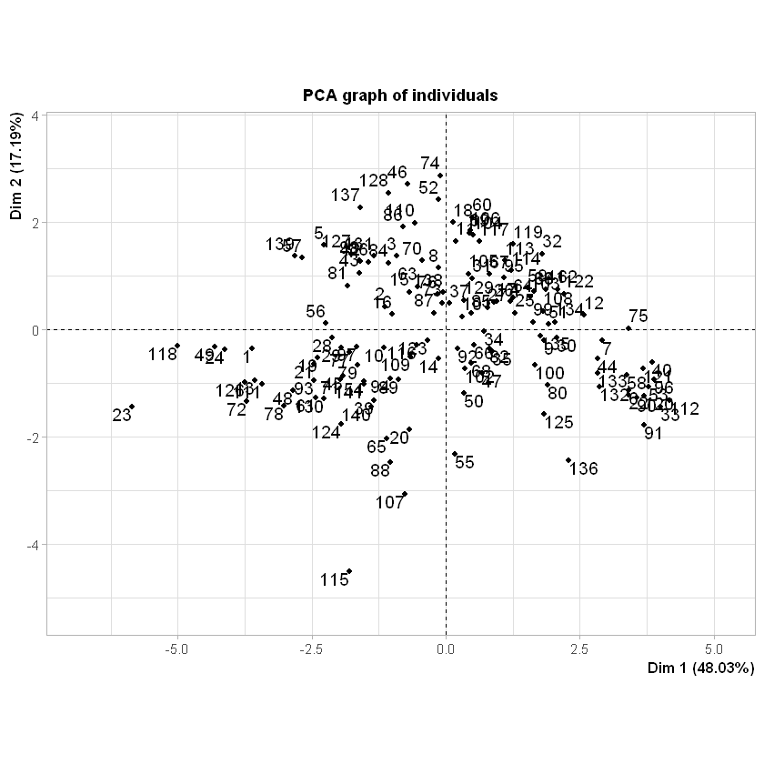

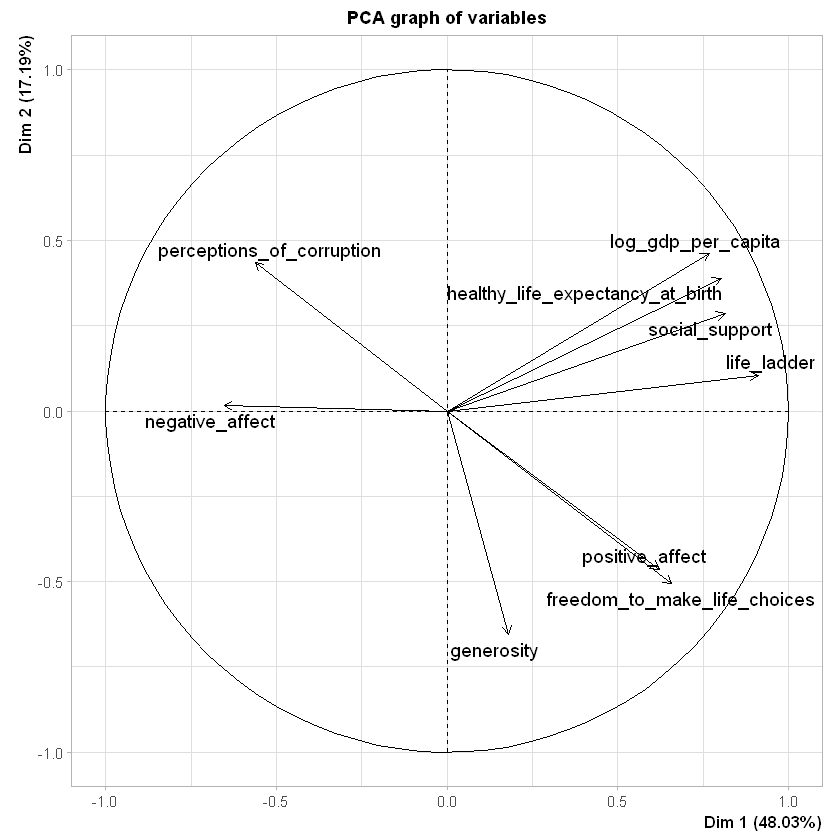

```r
res.pca = PCA(Datos,  graph = TRUE)
```

Life Ladder está bien representado por el CP1 como se observa en el grafico anterior

```r
summary(res.pca)
```

```
Call:
PCA(X = Datos, graph = TRUE)


Eigenvalues
                       Dim.1   Dim.2   Dim.3   Dim.4   Dim.5   Dim.6   Dim.7
Variance               4.323   1.547   0.849   0.685   0.634   0.351   0.282
% of var.             48.032  17.189   9.434   7.607   7.050   3.896   3.129
Cumulative % of var.  48.032  65.221  74.655  82.263  89.312  93.208  96.338
                       Dim.8   Dim.9
Variance               0.174   0.156
% of var.              1.929   1.734
Cumulative % of var.  98.266 100.000

Individuals (the 10 first)
                                     Dist    Dim.1    ctr   cos2    Dim.2
1                                |  3.976 | -3.622  2.152  0.830 | -0.353
2                                |  2.028 | -1.145  0.215  0.319 |  0.427
3                                |  2.255 | -0.925  0.140  0.168 |  1.368
4                                |  2.309 |  1.211  0.241  0.275 |  0.521
5                                |  3.036 | -2.281  0.854  0.565 |  1.576
6                                |  3.830 |  3.412  1.910  0.794 | -1.142
7                                |  3.001 |  2.916  1.395  0.944 | -0.204
8                                |  2.363 | -0.141  0.003  0.004 |  1.148
9                                |  2.235 |  1.827  0.548  0.668 | -0.208
10                               |  2.588 | -1.158  0.220  0.200 | -0.334
                                    ctr   cos2    Dim.3    ctr   cos2
1                                 0.057  0.008 |  0.664  0.368  0.028 |
2                                 0.083  0.044 |  0.518  0.224  0.065 |
3                                 0.858  0.368 |  0.232  0.045  0.011 |
4                                 0.124  0.051 | -0.778  0.506  0.114 |
5                                 1.139  0.270 |  0.707  0.418  0.054 |
6                                 0.598  0.089 |  1.195  1.192  0.097 |
7                                 0.019  0.005 |  0.363  0.110  0.015 |
8                                 0.604  0.236 | -0.935  0.730  0.157 |
9                                 0.020  0.009 | -0.063  0.003  0.001 |
10                                0.051  0.017 | -0.453  0.172  0.031 |

Variables
                                    Dim.1    ctr   cos2    Dim.2    ctr   cos2
log_gdp_per_capita               |  0.768 13.637  0.589 |  0.461 13.760  0.213
social_support                   |  0.815 15.351  0.664 |  0.286  5.285  0.082
healthy_life_expectancy_at_birth |  0.803 14.912  0.645 |  0.389  9.797  0.152
freedom_to_make_life_choices     |  0.658 10.022  0.433 | -0.507 16.591  0.257
generosity                       |  0.181  0.759  0.033 | -0.655 27.693  0.428
perceptions_of_corruption        | -0.562  7.312  0.316 |  0.434 12.181  0.188
positive_affect                  |  0.622  8.950  0.387 | -0.465 13.962  0.216
negative_affect                  | -0.653  9.853  0.426 |  0.016  0.016  0.000
life_ladder                      |  0.911 19.203  0.830 |  0.105  0.714  0.011
                                    Dim.3    ctr   cos2
log_gdp_per_capita               |  0.276  8.974  0.076 |
social_support                   | -0.114  1.533  0.013 |
healthy_life_expectancy_at_birth |  0.242  6.878  0.058 |
freedom_to_make_life_choices     | -0.134  2.118  0.018 |
generosity                       |  0.581 39.806  0.338 |
perceptions_of_corruption        | -0.072  0.617  0.005 |
positive_affect                  | -0.286  9.629  0.082 |
negative_affect                  |  0.489 28.181  0.239 |
life_ladder                      |  0.139  2.264  0.019 |
```

Los componentes 1 y 2 contienten cerca de 2/3 partes de la información de la varianza. Igualmente confirmamos la cercanía a 1 de life ladder con respecto al CP1

```r
x1=res.pca$ind$coord[,1]
x2=res.pca$ind$coord[,2]

especificacion="life_ladder ~ x1 + x2"
OLS.PCA <- lm(especificacion, data = Datos)
stargazer(OLS.PCA, type = 'text')
```

```
===============================================
                        Dependent variable:
                    ---------------------------
                            life_ladder
-----------------------------------------------
x1                           0.500***
                              (0.019)

x2                           0.096***
                              (0.031)

Constant                     5.400***
                              (0.039)

-----------------------------------------------
Observations                    141
R2                             0.841
Adjusted R2                    0.839
Residual Std. Error      0.459 (df = 138)
F Statistic          365.457*** (df = 2; 138)
===============================================
Note:               *p<0.1; **p<0.05; ***p<0.01
```

Con componentes principales podemos observar que el R2 tiene una mejora considerable, igualmente cada componente presenta relevancia estadística.

```r
x1=res.pca$ind$coord[,1]
x2=res.pca$ind$coord[,2]
x3=res.pca$ind$coord[,3]

especificacion="life_ladder ~ x1 + x2 + x3"
OLS.PCA <- lm(especificacion, data = Datos)
stargazer(OLS.PCA, type = 'text')
```

```
===============================================
                        Dependent variable:
                    ---------------------------
                            life_ladder
-----------------------------------------------
x1                           0.500***
                              (0.018)

x2                           0.096***
                              (0.029)

x3                           0.172***
                              (0.040)

Constant                     5.400***
                              (0.036)

-----------------------------------------------
Observations                    141
R2                             0.860
Adjusted R2                    0.857
Residual Std. Error      0.432 (df = 137)
F Statistic          281.461*** (df = 3; 137)
===============================================
Note:               *p<0.1; **p<0.05; ***p<0.01
```

Por curiosidad cietífica, decidimos agregar el tercer componente que contiene un 10% adicional de información, sin embargo queda demostrado que su aporte a R2 así como el error estándar no son tan altos, por lo que recomendamos mantenerlo con 2 componentes pricipales. El principal motivo por el que se ve una mejora con respecto al modelo tanto de los autores como de regresión lineal propuesto por nosotros es que se logra una matriz de ponderados con verdadera independencia lineal entre las variables, es decir que los valores fuera de la diagonal son ceros.

## Conclusiones

1. Para que pueda ocurrir una regresión lineal, es importante validar que se cumplan las propuestas de la teoría de Gauss y Markov, donde principalmente es necesaria la unicolinealidad y la homocedasticidad.
2. La regresión lineal es aplicable en un momento de tiempo.
3. La regresión lineal con componentes principales son una potente combinación.